# Projeção de Crescimento da População Brasileira

Mário O. de Menezes

28 de março de 2019

## Estudo do crescimento da população brasileira

Este pequeno estudo teve como motivação um *post* que vi no LinkedIn em 28 de março de 2019, que mostrava uma animação sobre o crescimento da população brasileira, destacando a quantidade de pessoas na faixa considerada economicamente ativa, isto é, que pagam a Previdência.

O contexto do post era exatamente a discussão sobre a Reforma da Previdência, e o autor tentava evidenciar a necessidade da reforma utilizando a pirâmide da população até 2060.

O link do post é: https://www.linkedin.com/feed/update/urn:li:activity:6515943618824404992

## Baixando os dados

O IBGE disponibiliza os dados de projeção da população de forma bastante detalhada em seu site. A página que trata da População é https://www.ibge.gov.br/estatisticas-novoportal/sociais/populacao.html

A partir desta página podemos chegar à página das projeções da população, cujo link é https://www.ibge.gov.br/estatisticas-novoportal/sociais/populacao/9109-projecao-da-populacao.html

Vamos então fazer o download dos dados. Utilizaremos a Revisão de 2018 e baixamos os dados em formato *ods*. A planilha contém diversas abas e uma delas é de projeções para homens, mulheres, total, e por faixas etárias, que é nosso interesse.

O arquivo baixado é `projecoes_2018_populacao_2010_2060.ods`. Para facilitar, criei 2 arquivos em CSV com os dados de interesse: projeção para mulheres (`projecao-rev2018-mulheres-populacao-2000-2060.csv`) e projeção para homens (`projecao-rev2018-homens-populacao-2000-2060.csv`).

## Leitura dos dados

Vamos ler os dados e examiná-los.

```r
library(tidyverse)
library(gganimate)
library(ggpubr)
library(glue)
library(scales)
```

```r
projecao_mulheres <- read_csv("data/projecao-rev2018-mulheres-populacao-2000-2060.csv")
projecao_homens <- read_csv("data/projecao-rev2018-homens-populacao-2000-2060.csv")
```

## Pequeno exame dos dados

```r
head(projecao_mulheres)
```

```
## # A tibble: 6 x 52
##   `GRUPO ETÁRIO` `2010` `2011` `2012` `2013` `2014` `2015` `2016` `2017` `2018`
##   <chr>           <dbl>  <dbl>  <dbl>  <dbl>  <dbl>  <dbl>  <dbl>  <dbl>  <dbl>
## 1 Total          9.94e7 1.00e8 1.01e8 1.02e8 1.03e8 1.04e8 1.05e8 1.06e8 1.07e8
## 2 0-4            7.26e6 7.18e6 7.15e6 7.12e6 7.12e6 7.17e6 7.19e6 7.19e6 7.22e6
## 3 5-9            7.77e6 7.64e6 7.53e6 7.44e6 7.35e6 7.25e6 7.17e6 7.13e6 7.11e6
## 4 10-14          8.55e6 8.46e6 8.28e6 8.09e6 7.91e6 7.76e6 7.63e6 7.52e6 7.43e6
## 5 15-19          8.55e6 8.55e6 8.57e6 8.60e6 8.60e6 8.54e6 8.44e6 8.27e6 8.08e6
## 6 20-24          8.73e6 8.69e6 8.63e6 8.58e6 8.54e6 8.52e6 8.52e6 8.55e6 8.58e6
## # … with 42 more variables: `2019` <dbl>, `2020` <dbl>, `2021` <dbl>,
## #   `2022` <dbl>, `2023` <dbl>, `2024` <dbl>, `2025` <dbl>, `2026` <dbl>,
## #   `2027` <dbl>, `2028` <dbl>, `2029` <dbl>, `2030` <dbl>, `2031` <dbl>,
## #   `2032` <dbl>, `2033` <dbl>, `2034` <dbl>, `2035` <dbl>, `2036` <dbl>,
## #   `2037` <dbl>, `2038` <dbl>, `2039` <dbl>, `2040` <dbl>, `2041` <dbl>,
## #   `2042` <dbl>, `2043` <dbl>, `2044` <dbl>, `2045` <dbl>, `2046` <dbl>,
## #   `2047` <dbl>, `2048` <dbl>, `2049` <dbl>, `2050` <dbl>, `2051` <dbl>,
## #   `2052` <dbl>, `2053` <dbl>, `2054` <dbl>, `2055` <dbl>, `2056` <dbl>,
## #   `2057` <dbl>, `2058` <dbl>, `2059` <dbl>, `2060` <dbl>
```

## Acertando os dados para o formato “tidy”

Os dados do IBGE vem no formato *wide*, precisamos organizá-los em formato *long*. Além desta organização, vamos adicionar uma coluna *Sexo* para podermos unificar as bases mas distinguindo as informações de cada sexo.

Também vamos adicionar uma coluna com o valor proporcional em relação à população. Faremos isso para as duas bases, Homens e Mulheres. Como queremos esta proporção em relação à população total, vamos ter que manipular um pouco as bases, criando alguns conjuntos intermediários para este cálculo.

### Base dos Homens

```r
popHomens <- projecao_homens %>% gather("Ano","Populacao", 2:52,)
popHomens <- popHomens %>% mutate(Sexo = "Homens")
names(popHomens) <- c("FxEtaria","Ano","PopulacaoH","Sexo")
popHomens <- as_tibble(popHomens)
populacoes <- select(popHomens,FxEtaria,Ano,PopulacaoH)
```

Rápida inspeção

```r
head(popHomens)
```

```
## # A tibble: 6 x 4
##   FxEtaria Ano   PopulacaoH Sexo
##   <chr>    <chr>      <dbl> <chr>
## 1 Total    2010    95513298 Homens
## 2 0-4      2010     7594516 Homens
## 3 5-9      2010     8094637 Homens
## 4 10-14    2010     8842587 Homens
## 5 15-19    2010     8673836 Homens
## 6 20-24    2010     8746116 Homens
```

```r
head(populacoes)
```

```
## # A tibble: 6 x 3
##   FxEtaria Ano   PopulacaoH
##   <chr>    <chr>      <dbl>
## 1 Total    2010    95513298
## 2 0-4      2010     7594516
## 3 5-9      2010     8094637
## 4 10-14    2010     8842587
## 5 15-19    2010     8673836
## 6 20-24    2010     8746116
```

### Base das Mulheres

```r
popMulheres <- projecao_mulheres %>% gather("Ano","Populacao",2:52)
popMulheres <- popMulheres %>% mutate(Sexo = "Mulheres")
names(popMulheres) <- c("FxEtaria","Ano","PopulacaoM","Sexo")
popMulheres <- as_tibble(popMulheres)
populacoes <- left_join(populacoes, select(popMulheres, FxEtaria, Ano, PopulacaoM), by = c("FxEtaria"="FxEtaria", "Ano" = "Ano"))
```

```r
head(popMulheres)
```

```
## # A tibble: 6 x 4
##   FxEtaria Ano   PopulacaoM Sexo
##   <chr>    <chr>      <dbl> <chr>
## 1 Total    2010    99377384 Mulheres
## 2 0-4      2010     7263764 Mulheres
## 3 5-9      2010     7770558 Mulheres
## 4 10-14    2010     8554717 Mulheres
## 5 15-19    2010     8545250 Mulheres
## 6 20-24    2010     8730663 Mulheres
```

```r
head(populacoes)
```

```
## # A tibble: 6 x 4
##   FxEtaria Ano   PopulacaoH PopulacaoM
##   <chr>    <chr>      <dbl>      <dbl>
## 1 Total    2010    95513298   99377384
## 2 0-4      2010     7594516    7263764
## 3 5-9      2010     8094637    7770558
## 4 10-14    2010     8842587    8554717
## 5 15-19    2010     8673836    8545250
## 6 20-24    2010     8746116    8730663
```

Agora os cálculos das proporções das populações, para cada faixa etária, para cada ano e por gênero.

```r
PopTotais <- filter(populacoes, FxEtaria == "Total")
PopTotais <- mutate(PopTotais, PopulacaoT = PopulacaoH + PopulacaoM)
anos <- populacoes$Ano
for (ano in unique(anos)) {
  populacoes[which(populacoes$Ano == ano),"PopulacaoT"] = PopTotais[which(PopTotais$Ano == ano),"PopulacaoT"]
}
popProps <- mutate(populacoes, PopulacaoPropH = PopulacaoH/PopulacaoT, PopulacaoPropM = PopulacaoM/PopulacaoT)
head(popProps)
```

```
## # A tibble: 6 x 7
##   FxEtaria Ano   PopulacaoH PopulacaoM PopulacaoT PopulacaoPropH PopulacaoPropM
##   <chr>    <chr>      <dbl>      <dbl>      <dbl>          <dbl>          <dbl>
## 1 Total    2010    95513298   99377384  194890682         0.490          0.510
## 2 0-4      2010     7594516    7263764  194890682         0.0390         0.0373
## 3 5-9      2010     8094637    7770558  194890682         0.0415         0.0399
## 4 10-14    2010     8842587    8554717  194890682         0.0454         0.0439
## 5 15-19    2010     8673836    8545250  194890682         0.0445         0.0438
## 6 20-24    2010     8746116    8730663  194890682         0.0449         0.0448
```

## Juntando as bases

Uma modificação importante que fazemos é deixar os valores relativos aos **Homens** todos como **negativos**. Isso nos permitirá plotar as barras de Homens e Mulheres ao mesmo tempo, uma para cada direção.

```r
popBRM <- full_join(popMulheres,select(popProps, FxEtaria, Ano, PopulacaoM, PopulacaoT, PopulacaoPropM) , by =c("FxEtaria" = "FxEtaria","Ano"= "Ano", "PopulacaoM" = "PopulacaoM"))
popBRH <- full_join(popHomens,select(popProps, FxEtaria, Ano, PopulacaoH, PopulacaoT, PopulacaoPropH) , by =c("FxEtaria" = "FxEtaria","Ano"= "Ano", "PopulacaoH" = "PopulacaoH"))
popBRH <- mutate(popBRH, PopulacaoH = -1 * PopulacaoH)
popBR <- full_join(popBRM,popBRH,by = c("FxEtaria" = "FxEtaria", "Ano" = "Ano", "Sexo" = "Sexo","PopulacaoT" = "PopulacaoT"))
popBR <- mutate(popBR, Populacao = coalesce(popBR$PopulacaoM,popBR$PopulacaoH), PopulacaoProp = coalesce(popBR$PopulacaoPropM,popBR$PopulacaoPropH))
popBR <- select(popBR, -PopulacaoM, -PopulacaoH, -PopulacaoPropM, -PopulacaoPropH)
popBR$Sexo = as.factor(popBR$Sexo)
popBR$Sexo <- relevel(popBR$Sexo, "Mulheres")
```

Removendo as linhas onde tem os totais da população para cada ano, já que não precisamos deste valor.

```r
popBR <- popBR %>% filter(FxEtaria != "Total")
```

Pequeno exame para nos certificarmos de que está como planejado.

```r
head(popBR)
```

```
## # A tibble: 6 x 6
##   FxEtaria Ano   Sexo     PopulacaoT Populacao PopulacaoProp
##   <chr>    <chr> <fct>         <dbl>     <dbl>         <dbl>
## 1 0-4      2010  Mulheres  194890682   7263764        0.0373
## 2 5-9      2010  Mulheres  194890682   7770558        0.0399
## 3 10-14    2010  Mulheres  194890682   8554717        0.0439
## 4 15-19    2010  Mulheres  194890682   8545250        0.0438
## 5 20-24    2010  Mulheres  194890682   8730663        0.0448
## 6 25-29    2010  Mulheres  194890682   8759504        0.0449
```

```r
tail(popBR)
```

```
## # A tibble: 6 x 6
##   FxEtaria Ano   Sexo   PopulacaoT Populacao PopulacaoProp
##   <chr>    <chr> <fct>       <dbl>     <dbl>         <dbl>
## 1 65-69    2060  Homens  228286347  -6767303       0.0296
## 2 70-74    2060  Homens  228286347  -6124121       0.0268
## 3 75-79    2060  Homens  228286347  -5066803       0.0222
## 4 80-84    2060  Homens  228286347  -3549148       0.0155
## 5 85-89    2060  Homens  228286347  -2076107       0.00909
## 6 90+      2060  Homens  228286347  -1600637       0.00701
```

## Gráficos da população

Uma maneira muito comum de se mostrar a distribuição da população em termos de faixas etárias é através de gráficos de pirâmides.

No **ggplot2** construimos estes gráficos utilizando o artifício dos sinais invertidos dos sexos: Masculino tudo negativo e Feminino tudo positivo. Com isso temos barras que vão na direção oposta e com uma rotação no sistema de coordenadas colocamos na posição desejada, como mostrado no gráfico abaixo.

### Exemplo de gráfico para o ano 2010

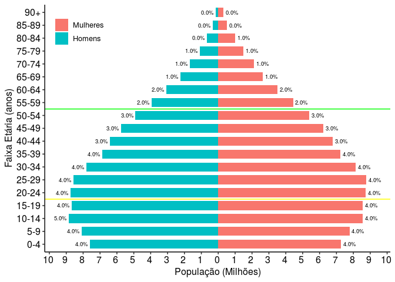

```r
ggplot(data = filter(popBR, Ano == "2010"), aes(x = as_factor(FxEtaria), y = Populacao, fill = Sexo, group = Populacao)) +
  geom_bar(stat = "identity", width=0.7) +
  scale_y_continuous(breaks = seq(-10000000,10000000,1000000),
                     labels = paste0(as.character(c(10:0,1:10))," ")) +
  geom_text( aes(label = scales::percent(round(PopulacaoProp,2), acuracy = 0.01), y = Populacao + 500000*sign(Populacao) , group = Populacao),  color="black", size=2.5) +
  geom_vline(aes(xintercept = 4.5), color = "yellow" ) + geom_vline(aes(xintercept = 11.5), color = "green") +
  labs_pubr() + labs(y = "População (Milhões)", x = "Faixa Etária (anos)") + theme_pubr() + theme(legend.position = c(0.1,.9), legend.title = element_blank()) +
  coord_flip()
```

E agora, o objetivo deste artigo: gerar uma animação com os gráficos dos vários anos disponibilizados na projeção do IBGE.

Para isso, vamos utilizar o pacote **gganimate**, que gera, a partir de uma sequência de gráficos do **ggplot2**, uma animação (GIF, MP4, etc) muito legal e intuitiva.

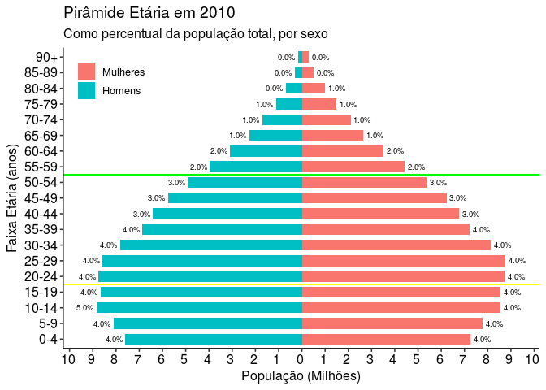

```r
knitr::opts_chunk$set(cache = TRUE, message = FALSE, warning = FALSE, fig.show = "animate")
p <- ggplot(data = popBR, aes(x = as_factor(FxEtaria), y = Populacao, fill = Sexo, group = Populacao)) +
  geom_bar(stat = "identity", width = 0.7) +
  scale_y_continuous(breaks = seq(-10000000,10000000,1000000),
                     labels = paste0(as.character(c(10:0,1:10))," ")) +
  geom_text(aes(label=scales::percent(round(PopulacaoProp,2), acuracy = 0.05), y = Populacao + 500000*sign(Populacao) , group = Populacao), color="black", size=2.5) +
  geom_vline(aes(xintercept = 4.5), color = "yellow" ) + geom_vline(aes(xintercept = 11.5), color = "green") +
  coord_flip()
p <- p + transition_states(Ano) + labs_pubr() + labs(x = "Faixa Etária (anos)", y = "População (Milhões)") + theme_pubr() +  theme(legend.position = c(0.1,.9), legend.title = element_blank()) +
ggtitle('Pirâmide Etária em {closest_state}', subtitle = 'Como percentual da população total, por sexo') +  ease_aes('linear')
animate(p, fps = 3)
```